# Elliott Classs Project

John Elliott

August 30, 2016

## Background of the project:

This work is created for the final class project in the Practical Machine Learning Course, as part of the Coursera Data Science Track. To demonstrate machine learning techniques learned during the course data from http://groupware.les.inf.puc-rio.br/har is used to construct a model that can discern between the different classe type. The data is from fitbit type devices worn by weightlifters performing exercises where they purposely performed the exercise with a particular type of fault winch makes up the **classe** variable. The data experiment was published in the following paper: **Velloso, E.; Bulling, A.; Gellersen, H.; Ugulino, W.; Fuks, H. Qualitative Activity Recognition of Weight Lifting Exercises. Proceedings of 4th International Conference in Cooperation with SIGCHI (Augmented Human ’13) . Stuttgart, Germany: ACM SIGCHI, 2013.** and you can read more about it here: http://groupware.les.inf.puc-rio.br/har#weight_lifting_exercises

## Execitive summary of the results:

To predict the outcome of the testing data, 3 models were developed. The first was a classification tree that used all predictor variables. It was not able to predict one of the classe types **“D”**. The classification tree was pruned by choosing predictor variables selected from feature plots where separation could be seen. The second model, the pruned classification tree was able to predict all classe types. The validation of the two classification trees was disappointing the first showed better accuracy but couldn’t predict all classe types, both models had accuracy below 60%. A third model was created using a Random Forest method. This model yielded excellent results with the data set with an accuracy of 99%.

## Code:

#### Data Download:

Data is downloaded from the defined URLs. The code makes a check to see if the required data file is present in the working directory. If it is not found then the file is downloaded and placed into the working directory.

```r
        URL <- c("https://d396qusza40orc.cloudfront.net/predmachlearn/pml-training.csv",
                 "https://d396qusza40orc.cloudfront.net/predmachlearn/pml-testing.csv")

        required_files <- c("pml-training.csv", "pml-testing.csv")

        for(i in 1:length(URL)){
                if(!all(lapply(required_files[i],file.exists)==TRUE)){
                        print("Required Data Files Not Found!")
                        print("Please wait while the files are downloaded")
                        download.file(URL[i], destfile = required_files[i], mode="wb")
                }
        }
```

#### Load Data Into Envioroment (Reading In Data)

A check for the required data is made and if not found it is read into the environment. Also “cache = TRUE” is set for the data chunk to provide data caching.

```r
        if(!exists("trainingData")){
                print("Please Wait while dataset is loaded")
                trainingData <- read.csv("pml-training.csv", header = TRUE, sep = "," ,
                                dec = ".",na.strings = c("", NA) )
        }
```

```
[1] "Please Wait while dataset is loaded"
```

```r
        if(!exists("testingData")){
                print("Please Wait while dataset is loaded")
                testingData <-  read.csv("pml-testing.csv", header = TRUE, sep = "," ,
                                dec = ".", na.strings = c("", NA) )
        }
```

```
[1] "Please Wait while dataset is loaded"
```

#### Inspection of the dataset

First we take a quick look at the data set to see what we have.

```
[1]  20 160
```

```
  X user_name raw_timestamp_part_1 raw_timestamp_part_2   cvtd_timestamp new_window num_window
1 1     pedro           1323095002               868349 05/12/2011 14:23         no         74
2 2    jeremy           1322673067               778725 30/11/2011 17:11         no        431
3 3    jeremy           1322673075               342967 30/11/2011 17:11         no        439
4 4    adelmo           1322832789               560311 02/12/2011 13:33         no        194
5 5    eurico           1322489635               814776 28/11/2011 14:13         no        235
6 6    jeremy           1322673149               510661 30/11/2011 17:12         no        504
  roll_belt pitch_belt yaw_belt total_accel_belt kurtosis_roll_belt kurtosis_picth_belt
1    123.00      27.00    -4.75               20                 NA                  NA
2      1.02       4.87   -88.90                4                 NA                  NA
3      0.87       1.82   -88.50                5                 NA                  NA
4    125.00     -41.60   162.00               17                 NA                  NA
5      1.35       3.33   -88.60                3                 NA                  NA
6     -5.92       1.59   -87.70                4                 NA                  NA
  kurtosis_yaw_belt skewness_roll_belt
1                NA                 NA
2                NA                 NA
3                NA                 NA
4                NA                 NA
5                NA                 NA
6                NA                 NA
```

```
'data.frame':   20 obs. of  15 variables:
 $ X                   : int  1 2 3 4 5 6 7 8 9 10 ...
 $ user_name           : Factor w/ 6 levels "adelmo","carlitos",..: 6 5 5 1 4 5 5 5 2 3 ...
 $ raw_timestamp_part_1: int  1323095002 1322673067 1322673075 1322832789 1322489635 1322673149 1322673128 1322673076 1323084240 1322837822 ...
 $ raw_timestamp_part_2: int  868349 778725 342967 560311 814776 510661 766645 54671 916313 384285 ...
 $ cvtd_timestamp      : Factor w/ 11 levels "02/12/2011 13:33",..: 5 10 10 1 6 11 11 10 3 2 ...
 $ new_window          : Factor w/ 1 level "no": 1 1 1 1 1 1 1 1 1 1 ...
 $ num_window          : int  74 431 439 194 235 504 485 440 323 664 ...
 $ roll_belt           : num  123 1.02 0.87 125 1.35 -5.92 1.2 0.43 0.93 114 ...
 $ pitch_belt          : num  27 4.87 1.82 -41.6 3.33 1.59 4.44 4.15 6.72 22.4 ...
 $ yaw_belt            : num  -4.75 -88.9 -88.5 162 -88.6 -87.7 -87.3 -88.5 -93.7 -13.1 ...
 $ total_accel_belt    : int  20 4 5 17 3 4 4 4 4 18 ...
 $ kurtosis_roll_belt  : logi  NA NA NA NA NA NA ...
 $ kurtosis_picth_belt : logi  NA NA NA NA NA NA ...
 $ kurtosis_yaw_belt   : logi  NA NA NA NA NA NA ...
 $ skewness_roll_belt  : logi  NA NA NA NA NA NA ...
```

```
  [1] "X"                        "user_name"                "raw_timestamp_part_1"
  [4] "raw_timestamp_part_2"     "cvtd_timestamp"           "new_window"
  [7] "num_window"               "roll_belt"                "pitch_belt"
 [10] "yaw_belt"                 "total_accel_belt"         "kurtosis_roll_belt"
 [13] "kurtosis_picth_belt"      "kurtosis_yaw_belt"        "skewness_roll_belt"
 [16] "skewness_roll_belt.1"     "skewness_yaw_belt"        "max_roll_belt"
 [19] "max_picth_belt"           "max_yaw_belt"             "min_roll_belt"
 [22] "min_pitch_belt"           "min_yaw_belt"             "amplitude_roll_belt"
 [25] "amplitude_pitch_belt"     "amplitude_yaw_belt"       "var_total_accel_belt"
 [28] "avg_roll_belt"            "stddev_roll_belt"         "var_roll_belt"
 [31] "avg_pitch_belt"           "stddev_pitch_belt"        "var_pitch_belt"
 [34] "avg_yaw_belt"             "stddev_yaw_belt"          "var_yaw_belt"
 [37] "gyros_belt_x"             "gyros_belt_y"             "gyros_belt_z"
 [40] "accel_belt_x"             "accel_belt_y"             "accel_belt_z"
 [43] "magnet_belt_x"            "magnet_belt_y"            "magnet_belt_z"
```

[output cut: 39 more lines]

```
  X user_name raw_timestamp_part_1 raw_timestamp_part_2   cvtd_timestamp new_window num_window
1 1  carlitos           1323084231               788290 05/12/2011 11:23         no         11
2 2  carlitos           1323084231               808298 05/12/2011 11:23         no         11
3 3  carlitos           1323084231               820366 05/12/2011 11:23         no         11
4 4  carlitos           1323084232               120339 05/12/2011 11:23         no         12
5 5  carlitos           1323084232               196328 05/12/2011 11:23         no         12
6 6  carlitos           1323084232               304277 05/12/2011 11:23         no         12
  roll_belt pitch_belt yaw_belt total_accel_belt kurtosis_roll_belt kurtosis_picth_belt
1      1.41       8.07    -94.4                3               <NA>                <NA>
2      1.41       8.07    -94.4                3               <NA>                <NA>
3      1.42       8.07    -94.4                3               <NA>                <NA>
4      1.48       8.05    -94.4                3               <NA>                <NA>
5      1.48       8.07    -94.4                3               <NA>                <NA>
6      1.45       8.06    -94.4                3               <NA>                <NA>
  kurtosis_yaw_belt skewness_roll_belt
1              <NA>               <NA>
2              <NA>               <NA>
3              <NA>               <NA>
4              <NA>               <NA>
5              <NA>               <NA>
6              <NA>               <NA>
```

```
'data.frame':   19622 obs. of  15 variables:
 $ X                   : int  1 2 3 4 5 6 7 8 9 10 ...
 $ user_name           : Factor w/ 6 levels "adelmo","carlitos",..: 2 2 2 2 2 2 2 2 2 2 ...
 $ raw_timestamp_part_1: int  1323084231 1323084231 1323084231 1323084232 1323084232 1323084232 1323084232 1323084232 1323084232 1323084232 ...
 $ raw_timestamp_part_2: int  788290 808298 820366 120339 196328 304277 368296 440390 484323 484434 ...
 $ cvtd_timestamp      : Factor w/ 20 levels "02/12/2011 13:32",..: 9 9 9 9 9 9 9 9 9 9 ...
 $ new_window          : Factor w/ 2 levels "no","yes": 1 1 1 1 1 1 1 1 1 1 ...
 $ num_window          : int  11 11 11 12 12 12 12 12 12 12 ...
 $ roll_belt           : num  1.41 1.41 1.42 1.48 1.48 1.45 1.42 1.42 1.43 1.45 ...
 $ pitch_belt          : num  8.07 8.07 8.07 8.05 8.07 8.06 8.09 8.13 8.16 8.17 ...
 $ yaw_belt            : num  -94.4 -94.4 -94.4 -94.4 -94.4 -94.4 -94.4 -94.4 -94.4 -94.4 ...
 $ total_accel_belt    : int  3 3 3 3 3 3 3 3 3 3 ...
 $ kurtosis_roll_belt  : Factor w/ 396 levels "-0.016850","-0.021024",..: NA NA NA NA NA NA NA NA NA NA ...
 $ kurtosis_picth_belt : Factor w/ 316 levels "-0.021887","-0.060755",..: NA NA NA NA NA NA NA NA NA NA ...
 $ kurtosis_yaw_belt   : Factor w/ 1 level "#DIV/0!": NA NA NA NA NA NA NA NA NA NA ...
 $ skewness_roll_belt  : Factor w/ 394 levels "-0.003095","-0.010002",..: NA NA NA NA NA NA NA NA NA NA ...
```

```
  [1] "X"                        "user_name"                "raw_timestamp_part_1"
  [4] "raw_timestamp_part_2"     "cvtd_timestamp"           "new_window"
  [7] "num_window"               "roll_belt"                "pitch_belt"
 [10] "yaw_belt"                 "total_accel_belt"         "kurtosis_roll_belt"
 [13] "kurtosis_picth_belt"      "kurtosis_yaw_belt"        "skewness_roll_belt"
 [16] "skewness_roll_belt.1"     "skewness_yaw_belt"        "max_roll_belt"
 [19] "max_picth_belt"           "max_yaw_belt"             "min_roll_belt"
 [22] "min_pitch_belt"           "min_yaw_belt"             "amplitude_roll_belt"
 [25] "amplitude_pitch_belt"     "amplitude_yaw_belt"       "var_total_accel_belt"
 [28] "avg_roll_belt"            "stddev_roll_belt"         "var_roll_belt"
 [31] "avg_pitch_belt"           "stddev_pitch_belt"        "var_pitch_belt"
 [34] "avg_yaw_belt"             "stddev_yaw_belt"          "var_yaw_belt"
 [37] "gyros_belt_x"             "gyros_belt_y"             "gyros_belt_z"
 [40] "accel_belt_x"             "accel_belt_y"             "accel_belt_z"
 [43] "magnet_belt_x"            "magnet_belt_y"            "magnet_belt_z"
```

[output cut: 39 more lines]

```r
testingData     <- testingData[, colSums(is.na(testingData)) == 0]
trainingData    <- trainingData[, colSums(is.na(trainingData)) == 0]

checknames      <- is.na(match(colnames(trainingData), colnames(testingData)))

trainingData    <- trainingData[,7:60]
testingData     <- testingData[,7:60]
```

We create a validation subset from the training data

```r
        set.seed(1972)

inTrain         <- createDataPartition(trainingData$classe, p = 0.7, list = FALSE)
trainingData    <- trainingData[inTrain, ]
validate        <- trainingData[-inTrain, ]
```

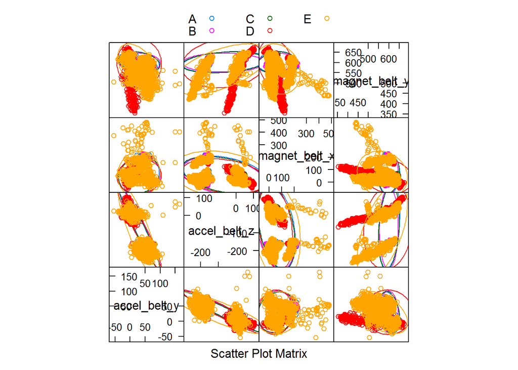

#### Model development of Classification Trees:

##### Model One:

The first model is a classification tree (method = “rpart”) using all predictors.

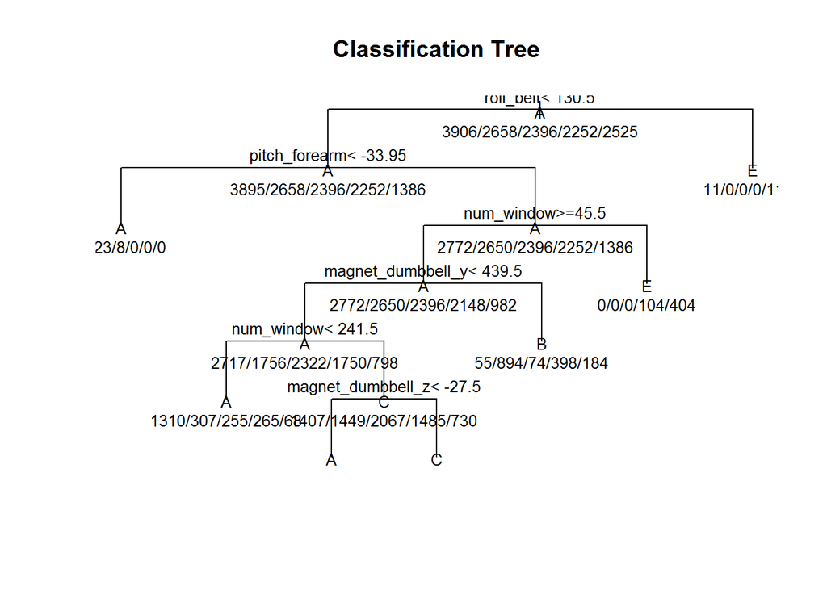

```r
        set.seed(1972)

model_1         <- train(as.factor(classe) ~ . ,  method = "rpart", data = trainingData)

        plot(model_1$finalModel, uniform=TRUE, main="Classification Tree")
        text(model_1$finalModel, use.n = TRUE, all = TRUE, cex = 0.8)
```

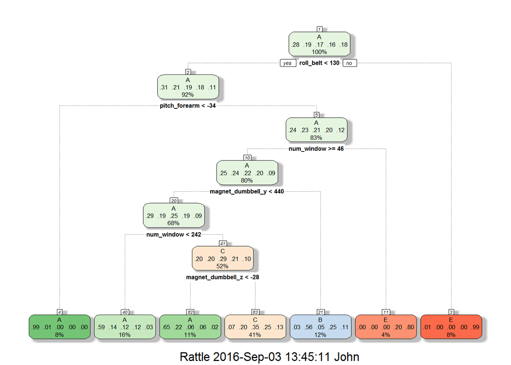

```r
        fancyRpartPlot(model_1$finalModel)
```

The first model was not able to discern classe type **“D”**, the alternate set of predictors were used to create the second model a pruned version of the first classification tree.

##### Model Two:

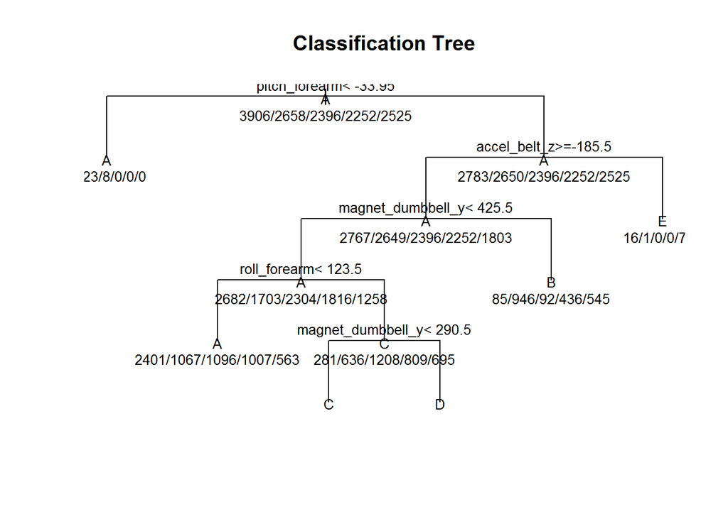

```r
model_2         <- train(as.factor(classe) ~ accel_belt_y + accel_belt_z + magnet_belt_x + magnet_belt_y + accel_dumbbell_z + magnet_dumbbell_x + magnet_dumbbell_y + magnet_dumbbell_z + roll_forearm + pitch_forearm + yaw_forearm + total_accel_forearm + gyros_forearm_x , method = "rpart", data = trainingData)

        plot(model_2$finalModel, uniform=TRUE, main="Classification Tree")
        text(model_2$finalModel, use.n = TRUE, all = TRUE, cex = 0.8)
```

[figure not shown]

```r
        fancyRpartPlot(model_2$finalModel)
```

#### Validation of the Classification Trees

Validation of the two models was performed using the validation data that was subset ted from the training data.

```r
mod1_prediction <- predict(model_1, validate)
mod2_prediction <- predict(model_2, validate)

mod1_confusion  <- confusionMatrix(validate$classe, mod1_prediction)
mod2_confusion  <- confusionMatrix(validate$classe, mod2_prediction)

accuracy_mod1   <- mod1_confusion$overall[1]
accuracy_mod2   <- mod2_confusion$overall[1]

        print("Model One")
```

```
[1] "Model One"
```

```r
        mod1_confusion[2]
```

```
$table
          Reference
Prediction    A    B    C    D    E
         A 1020   18  125    0    7
         B  195  264  345    0    0
         C  104   23  589    0    0
         D  109  118  414    0   26
         E   35   58  214    0  464
```

```r
        accuracy_mod1
```

```
 Accuracy
0.5661337
```

```r
        print("Model Two")
```

```
[1] "Model Two"
```

```r
        mod2_confusion[2]
```

```
$table
          Reference
Prediction    A    B    C    D    E
         A 1043   30   68   22    7
         B  320  283   79  122    0
         C  315   33  313   55    0
         D  317  129   91  130    0
         E  178  177  106  106  204
```

```r
        accuracy_mod2
```

```
 Accuracy
0.4779554
```

#### Predictions made with Classification Trees:

```r
        predict(model_1, testingData)
```

```
 [1] A A C A A C C C A A C C C A C C A A A C
Levels: A B C D E
```

```r
        predict(model_2, testingData)
```

```
 [1] C A D A A C D A A A C D C A D A E A A D
Levels: A B C D E
```

Model 1 has better accuracy at 0.5661337 compared to model 2 accuracy of 0.4779554 . With both models having ac curacies below 60% another modelling method was explored.

#### Model development of Random Forests

The last model explored is a Random Forest (method = “rf”) using all predictor variables.

##### Model Three:

```r
myControl       <- trainControl(method = "cv", number = 5)

mod3            <- train(as.factor(classe) ~ .,method="rf",trControl=myControl,data=trainingData)
```

#### Validation of the Random Forest

Validation of the Random Forest model was performed using the validation data that was subset ted from the training data.

```r
val_predict     <- predict(mod3, validate)
My_Confusion    <- confusionMatrix(validate$classe, val_predict)

        My_Confusion$overall[3]
```

```
AccuracyLower
    0.9991068
```

```r
        My_Confusion[2]
```

```
$table
          Reference
Prediction    A    B    C    D    E
         A 1170    0    0    0    0
         B    0  804    0    0    0
         C    0    0  716    0    0
         D    0    0    0  667    0
         E    0    0    0    0  771
```

```r
        predict(mod3, testingData)
```

```
 [1] B A B A A E D B A A B C B A E E A B B B
Levels: A B C D E
```

```r
# [1] B A B A A E D B A A B C B A E E A B B B
```

## Conclusions

The random Forest model out performed the Classification Tree model by leaps and bounds. The results are only based on the data set the models were trained on and it is expected the results would be different for data collected under different circumstances and the individuals who performed the exercises.